# Chapter 4 - Linear Models

## Example: A gaussian model of height

We’ll build a regression to predict a human’s hight, which we will model as a Gaussian distribution with two parameters, mean and standard deviation. There are an infinite number of possible Gaussian distributions. We want our Bayesian machine to consider every possible distribution, each defined by a combination of meand and sd, and rank them by posterior plausibility given the data.

```r
data(Howell1)
d <- Howell1
d2 <- d %>%
  filter(age >= 18)
d2 %>%
  skim
```

```
Skim summary statistics
 n obs: 352
 n variables: 4

Variable type: integer
 variable missing complete   n mean  sd p0 p25 p50 p75 p100     hist
     male       0      352 352 0.47 0.5  0   0   0   1    1 ▇▁▁▁▁▁▁▇

Variable type: numeric
 variable missing complete   n   mean    sd     p0    p25    p50    p75   p100     hist
      age       0      352 352  41.14 15.97  18     28     39     51     88    ▇▇▇▅▂▃▁▁
   height       0      352 352 154.6   7.74 136.53 148.59 154.31 160.66 179.07 ▁▅▇▆▆▃▁▁
   weight       0      352 352  44.99  6.46  31.07  40.26  44.79  49.29  62.99 ▂▆▇▇▇▃▂▁
```

Lets specifiy our model like so. The first line is the likelihood of our outcome, height. The second two lines are priors for the parameters in our likelihood.
$$h_i \sim Normal(\mu, \sigma) \\
\mu \sim Normal(178, 20) \\
\sigma \sim Uniform(0, 50)$$

As height is a physical phenomenon, we can use our intuition to assign a prior.

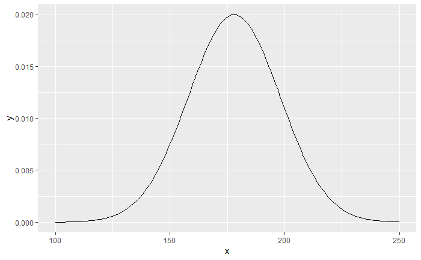

```r
data_frame(x=100:250,
           y=purrr::map_dbl(100:250, ~ dnorm(.x, 178, 20))) %>%
  ggplot(aes(x,y)) + geom_path()
```

We give the standard deviation a truly flat prior. We really just want to make sure its positive.

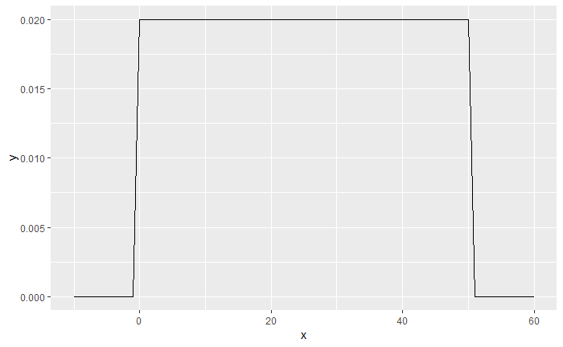

```r
data_frame(x=-10:60,
           y=purrr::map_dbl(-10:60, ~ dunif(.x, 0, 50))) %>%
  ggplot(aes(x,y)) + geom_path()
```

Specifying a prior for the parameters of our outcome implicitly give us a prior for our outcome.

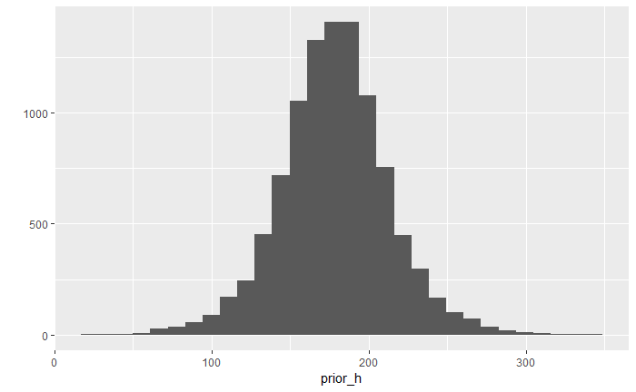

```r
sample_mu <- rnorm(1e4, 178, 20)
sample_sigma <- runif(1e4, 0, 50)
prior_h <- rnorm(1e4, sample_mu, sample_sigma)
qplot(prior_h)
```

Lets us grid approximation to generate the posterior. To do so, we enumerate a list of candidate values for our parameters and store them in post. We then calculate the log likelihood for each of those parameters given all the heights we have seen and store them in the column LL. We use log transformation to avoid rounding errors. Then we multiply by the priors (log addition is the same as multiplying)

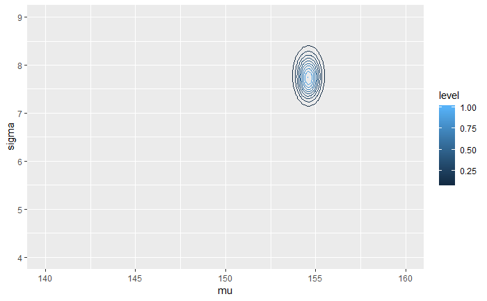

```r
# Generate candidate parameters
mu_list <- seq(from=140, to=160, length.out=200)
sigma_list <- seq(from=4, to=9, length.out=200)
post <- expand.grid(mu=mu_list, sigma=sigma_list)

# Calculate the likelihood of every possible
# combination candidate parameters
post$LL <- sapply(1:nrow(post), function(i) {
  sum(dnorm(
    d2$height,
    mean=post$mu[i],
    sd=post$sigma[i],
    log=TRUE))
  })

# Multiply priors
post$prod <- post$LL + dnorm(post$mu, 178, 20, TRUE) +
  dunif(post$sigma, 0, 50, TRUE)

# Calculated scaled posterior
post$prob <- exp(post$prod - max(post$prod))

# Contour plot of probabilities
ggplot(post, aes(x=mu, y=sigma, z=prob)) +
  geom_contour(aes(colour=stat(level))) +
  coord_cartesian(xlim=c(140, 160), ylim=c(4, 9))
```

Now lets sample from the posterior.

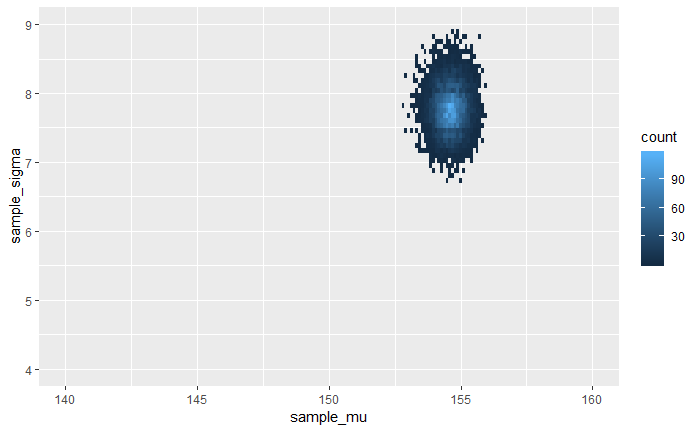

```r
# Sample candidate values by posterior
sample_rows <- sample(1:nrow(post), size=1e4, replace=TRUE, prob=post$prob)

# Plot their 2d histogram
data_frame(
  sample_mu = post$mu[sample_rows],
  sample_sigma = post$sigma[sample_rows]
) %>%
  ggplot(aes(sample_mu, sample_sigma)) +
    geom_bin2d(bins=30) +
    coord_cartesian(xlim=c(140, 160), ylim=c(4, 9))
```

Lets also examine the margins.

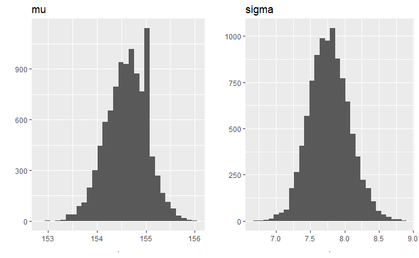

```r
require(gridExtra)
p1 <- post$mu[sample_rows] %>%
  qplot + ggtitle("mu")
p2 <- post$sigma[sample_rows] %>%
  qplot + ggtitle("sigma")

grid.arrange(p1, p2, ncol=2)
```

`map` from the rethinking package allows us to solve for the posterior using quadratic approximation instead of grid approximations. It shows us gaussian approximations for each parameter’s marginal distribution.

```r
flist <- alist(
  height ~ dnorm(mu, sigma),
  mu ~ dnorm(178, 20),
  sigma ~ dunif(0, 50)
)
m4.1 <- rethinking::map(flist, data=d2)
precis(m4.1)
```

|  | Mean | StdDev | 5.5% | 94.5% |
| --- | --- | --- | --- | --- |
| mu | 154.61 | 0.41 | 153.95 | 155.27 |
| sigma | 7.73 | 0.29 | 7.27 | 8.20 |

Variance covariance matrix tells us how each parameter relates to every other parameter in the posterior distribution.

```r
vcov(m4.1)
```

```
                mu        sigma
mu    0.1697665416 0.0002210108
sigma 0.0002210108 0.0849394999
```

```r
# This can be factored in to a vector of variances
diag(vcov(m4.1))
```

```
       mu     sigma
0.1697665 0.0849395
```

```r
# Or a correlation matrix
cov2cor(vcov(m4.1))
```

```
               mu       sigma
mu    1.000000000 0.001840487
sigma 0.001840487 1.000000000
```

Lets draw from the posterior by sampling vectors of values from a multi-dimensional gaussian distribution.

```r
post <- extract.samples(m4.1, n=1e4)
precis(post)
```

|  | Mean | StdDev | \|0.89 | 0.89\| |
| --- | --- | --- | --- | --- |
| mu | 154.61 | 0.42 | 153.97 | 155.29 |
| sigma | 7.73 | 0.29 | 7.26 | 8.19 |

### Adding a predictor variable, weight

It looks like weight will be a good predictor for height in adults.

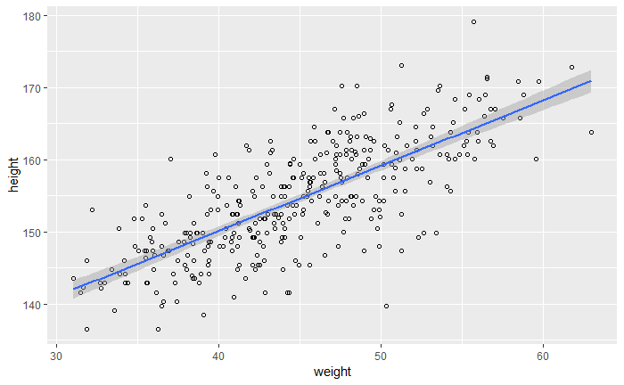

```r
ggplot(d2, aes(x=weight, y=height)) +
  geom_point(shape=1) +
  geom_smooth(method=lm)
```

The goal here is to make the parameter for the mean of a Gaussian distribution, $\mu$, into a linear function of the predictor variable. This encodes the assumption that the predictor variable has a perfectly constant and additive relationship to the mean of the outcome.

```r
m4.3 <- rethinking::map(
  alist(
    height ~ dnorm(mu, sigma),
    mu <- a + b*weight,
    a ~ dnorm(156, 100),
    b ~ dnorm(0, 10),
    sigma ~ dunif(0, 50)),
  data = d2)
# Display table of estimates
precis(m4.3, corr=TRUE)
```

|  | Mean | StdDev | 5.5% | 94.5% | a | b | sigma |
| --- | --- | --- | --- | --- | --- | --- | --- |
| a | 113.90 | 1.91 | 110.85 | 116.94 | 1.00 | -0.99 | 0 |
| b | 0.90 | 0.04 | 0.84 | 0.97 | -0.99 | 1.00 | 0 |
| sigma | 5.07 | 0.19 | 4.77 | 5.38 | 0.00 | 0.00 | 1 |

The table above tells us that a person 1 kg heavier is expected to be .9 cm taller. It also tells us that a person with 0 weight is 114 cm tall, which is of course nonsense; This is why it is usually important to have very weak priors for intercepts in many cases. Finally, it explains that 95% of plausible heights lie within 10 cm of the mean.

Centering is the procedure of subtracting the mean of a variable from each value.

```r
d2$weight.c <- d2$weight - mean(d2$weight)

m4.4 <- rethinking::map(
  alist(
    height ~ dnorm(mu, sigma),
    mu <- a + b*weight.c,
    a ~ dnorm(178, 100),
    b ~ dnorm(0, 10),
    sigma ~ dunif(0, 50)),
  data = d2)
# Display table of estimates
precis(m4.4, corr=TRUE)
```

|  | Mean | StdDev | 5.5% | 94.5% | a | b | sigma |
| --- | --- | --- | --- | --- | --- | --- | --- |
| a | 154.60 | 0.27 | 154.17 | 155.03 | 1 | 0 | 0 |
| b | 0.91 | 0.04 | 0.84 | 0.97 | 0 | 1 | 0 |
| sigma | 5.07 | 0.19 | 4.77 | 5.38 | 0 | 0 | 1 |

By **centering** our predictor variable, the interpretation of the intercept has now become the expected value of the outcome when the predictor is at its average value. This makes interpreting the intercept a lot easier.

### Visualizing our estimates

We can plot our maximum a posteriori fit here

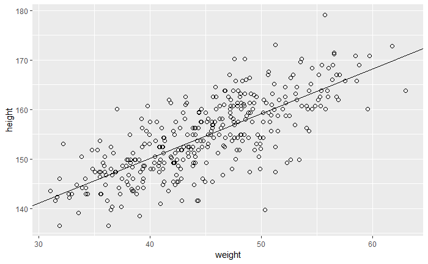

```r
p <- ggplot(d2, aes(x=weight, y=height)) +
  geom_point(shape=1, size=2) +
  geom_abline(aes(intercept = coef(m4.3)["a"],
                  slope = coef(m4.3)["b"]))
p
```

This line only represents one piece of the posterior. We could instead sample values of $\alpha$ and $\beta$ from the posterior to generate many lines to build bounds of uncertainty. We’ll do this with a much smaller dataset to magnify effects.

```r
N <- 10
dN <- d2[ 1:N , ]
mN <- rethinking::map(
  alist(
    height ~ dnorm( mu , sigma ) ,
    mu <- a + b*weight ,
    a ~ dnorm( 178 , 100 ) ,
    b ~ dnorm( 0 , 10 ) ,
    sigma ~ dunif( 0 , 50 )
) , data=dN )

post <- extract.samples(mN, n=20)
head(post)
```

|  | a | b | sigma |
| --- | --- | --- | --- |
| 1 | 107.0014 | 0.9947699 | 3.381453 |
| 2 | 104.5639 | 1.0189624 | 3.876759 |
| 3 | 103.4922 | 1.0520059 | 4.988938 |
| 4 | 108.6485 | 1.0034437 | 3.056349 |
| 5 | 111.3816 | 0.8926239 | 3.831040 |
| 6 | 113.0617 | 0.8467022 | 4.499845 |

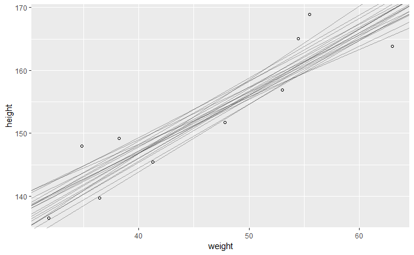

```r
p <- ggplot(dN, aes(weight, height)) +
  geom_point(shape=1)

for (i in 1:20) {
  p <- p + geom_abline(intercept = post$a[i], slope = post$b[i], alpha = I(3/10))
}

p
```

To do this more generally:

1. Sample parameter values from the posterior.
2. Use the parameter values to create predictions of the parameters of interest, including the final outcome.
3. Use summary functions like mean, HDOP, PI to find averages and lower and upper bounds of our uncertainty.

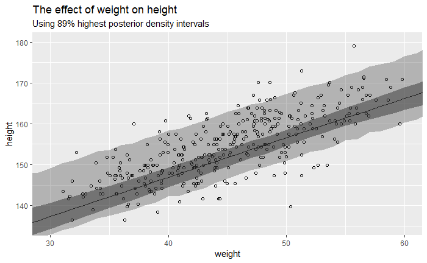

```r
# Draw parameter values from the posterior distribution
posterior_samples <- extract.samples(m4.3)

# Create out x-axis of interest
weights_axis <- 25:70

# Function to calculate fit values for \mu
mu_link <- function(weight) post$a + post$b*weight
mu <- purrr::map(weights_axis, mu_link)

# Function to calculate fit heights
# This incorporates variability as well
simulate <- function(weight, parameter_samples) {
  rnorm(n = nrow(parameter_samples),
        mean = parameter_samples$a + parameter_samples$b * weight,
        sd = parameter_samples$sigma)}
simulated_heights <- purrr::map(weights_axis, ~ simulate(.x, posterior_samples))

# Combine all this information to plot
data_frame(
  # X axis
  weight = weights_axis,
  # Estimates for mean height
  mu_mean = map_dbl(mu, mean),
  mu_lower = map_dbl(mu, ~HPDI(.x, .89)[1]),
  mu_upper = map_dbl(mu, ~HPDI(.x, .89)[2]),
  # Estimates for height
  height_mean = map_dbl(simulated_heights, mean),
  height_low = map_dbl(simulated_heights, ~HPDI(.x, .89)[1]),
  height_high = map_dbl(simulated_heights, ~HPDI(.x, .89)[2])) %>%
  ggplot(data=.) +
  geom_point(inherit.aes = FALSE, data = d2,
             aes(x=weight, y=height), shape=1) +
  geom_line(aes(x=weight, y=mu_mean)) +
  geom_ribbon(aes(x = weight, ymin=mu_lower, ymax=mu_upper), alpha=.5) +
  geom_ribbon(aes(x = weight, ymin = height_low, ymax = height_high), alpha=.3) +
  ggtitle("The effect of weight on height", subtitle = "Using 89% highest posterior density intervals") +
  coord_cartesian(xlim=c(30, 60),ylim=c(135, 180))
```

## Polynomial Regression

Standardizing our predictors means scaling but also dividing by the standard deviation. This changes our interpretation of continuous variables to mean the unit change in outcome from a cahnge of one standard deviation.

## On transformations

Centering and scaling a continuous variable increases interpretability. Demeaning a predictor variable subtracts every value by it’s mean. By demeaning a predictor variables, the intercept represents the value of the outcome when all variables are at their mean. One standardizes a variable by dividing every value by the variables standard deviation. Standardizing causes the interpretation of coefficients to be in terms of unit changes in SD of the variable.

Log transforming the outcome variable makes y our coefficients represent percent increases in the outcome. Log transforming a predictor variable describes how a single percentage point increase in the predictor affects y. Log transforming both the predictor and outcome describes how percentage changes in one create percentage changes in the other.

# Homework

## Medium

### 4M2

## Hard

### 4H1

# 4H2